# Week 6 DS Recitation: Regression

SIBDS 2024 @ Columbia

05 July, 2024

## Getting Started

1. Create a new R project and name it `week6_DS_recitation`
2. Put the `week6_DS_recitation_regression.Rmd` file into the same folder of the R project you just created.
3. Create a folder within the project folder named `data`.
4. Download the `birthweight.csv` dataset and put it in the `data` folder.

## Linear Regression

In this problem, you will analyze data gathered to understand the effects of several variables on a child’s birth weight. This dataset (`birthweight.csv`), consists of roughly 4000 children and includes the following variables:

- babysex: baby’s sex (male = 1, female = 2)
- bhead: baby’s head circumference at birth (centimeters)
- blength: baby’s length at birth (centimeteres)
- bwt: baby’s birth weight (grams)
- delwt: mother’s weight at delivery (pounds)
- fincome: family monthly income (in hundreds, rounded)
- frace: father’s race (1 = White, 2 = Black, 3 = Asian, 4 = Puerto Rican, 8 = Other, 9 = Unknown)
- gaweeks: gestational age in weeks
- malform: presence of malformations that could affect weight (0 = absent, 1 = present)
- menarche: mother’s age at menarche (years)
- mheigth: mother’s height (inches)
- momage: mother’s age at delivery (years)
- mrace: mother’s race (1 = White, 2 = Black, 3 = Asian, 4 = Puerto Rican, 8 = Other)
- parity: number of live births prior to this pregnancy
- pnumlbw: previous number of low birth weight babies
- pnumgsa: number of prior small for gestational age babies
- ppbmi: mother’s pre-pregnancy BMI
- ppwt: mother’s pre-pregnancy weight (pounds)
- smoken: average number of cigarettes smoked per day during pregnancy -wtgain: mother’s weight gain during pregnancy (pounds)

Load and clean the data using the code below for regression analysis.

```r
library(tidyverse)
baby_df =
  read_csv("./data/birthweight.csv") %>%
  mutate(
    babysex = case_when(babysex == 1~"male", babysex == 2~"female"),
    malform = case_when(malform == 0~"absent", malform == 1 ~ "present")
    ) %>%
  mutate(
    across(
      .cols = c("frace", "mrace"),
      ~ case_when(
        .x == 1 ~ "White",
        .x == 2 ~ "Black",
        .x == 3 ~ "Asian",
        .x == 4 ~ "Puero Rican",
        .x == 8 ~ "Other",
        .x == 9 ~ "Unknown"
        )
      ),
    across(where(is.character), as.factor)
    ) %>%
  select(
    -c(pnumlbw, pnumsga, wtgain))
```

### Model fitting

1. Propose a regression model for birthweight. This model may be based on a hypothesized structure for the factors that underlie birth weight, on a data-driven model-building process, or a combination of the two. Describe your modeling process and show a plot of model residuals against fitted values – use `add_predictions` and `add_residuals` in making this plot.

```r
# Your answer starts here
proposal_model =
  lm(bwt ~ babysex + bhead + blength + gaweeks, data = baby_df)

# Fit a model using all available predictors
proposal_model_1 =
  lm(bwt ~ ., data = baby_df)

# Variable selection: LASSO, Elastic Net

proposal_model %>% broom::tidy() %>% knitr::kable(digits = 3)
```

| term | estimate | std.error | statistic | p.value |
| --- | --- | --- | --- | --- |
| (Intercept) | -6230.735 | 96.654 | -64.465 | 0 |
| babysexmale | -33.420 | 8.839 | -3.781 | 0 |
| bhead | 140.867 | 3.566 | 39.508 | 0 |
| blength | 81.756 | 2.081 | 39.287 | 0 |
| gaweeks | 14.067 | 1.513 | 9.297 | 0 |

```r
proposal_model_1 %>% broom::tidy() %>% knitr::kable(digits = 3)
```

| term | estimate | std.error | statistic | p.value |
| --- | --- | --- | --- | --- |
| (Intercept) | -6306.835 | 659.264 | -9.566 | 0.000 |
| babysexmale | -28.707 | 8.465 | -3.391 | 0.001 |
| bhead | 130.778 | 3.452 | 37.881 | 0.000 |
| blength | 74.954 | 2.022 | 37.075 | 0.000 |
| delwt | 4.101 | 0.395 | 10.386 | 0.000 |
| fincome | 0.290 | 0.180 | 1.614 | 0.107 |
| fraceBlack | -6.905 | 78.835 | -0.088 | 0.930 |
| fraceOther | -16.939 | 97.593 | -0.174 | 0.862 |
| fracePuero Rican | -68.232 | 78.469 | -0.870 | 0.385 |
| fraceWhite | -21.236 | 69.296 | -0.306 | 0.759 |
| gaweeks | 11.549 | 1.465 | 7.882 | 0.000 |
| malformpresent | 9.765 | 70.626 | 0.138 | 0.890 |
| menarche | -3.551 | 2.895 | -1.226 | 0.220 |
| mheight | 9.787 | 10.312 | 0.949 | 0.343 |
| momage | 0.759 | 1.222 | 0.621 | 0.534 |
| mraceBlack | -60.049 | 80.953 | -0.742 | 0.458 |
| mracePuero Rican | 34.908 | 80.948 | 0.431 | 0.666 |
| mraceWhite | 91.387 | 71.919 | 1.271 | 0.204 |
| parity | 95.541 | 40.479 | 2.360 | 0.018 |
| ppbmi | 4.354 | 14.891 | 0.292 | 0.770 |
| ppwt | -3.472 | 2.612 | -1.329 | 0.184 |
| smoken | -4.854 | 0.587 | -8.269 | 0.000 |

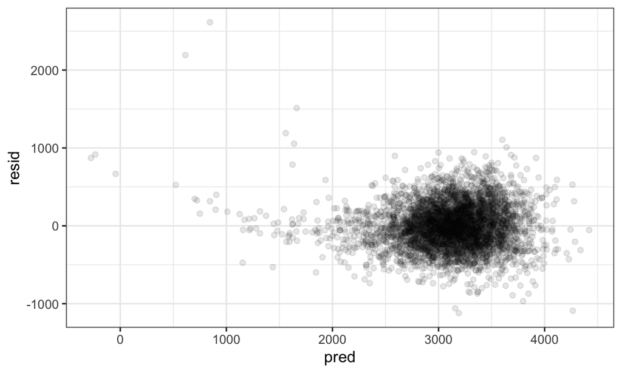

```r
proposal_plt =
  baby_df %>%
  modelr::add_predictions(proposal_model) %>%
  modelr::add_residuals(proposal_model)

proposal_plt %>%
  ggplot(aes(x = pred, y = resid)) +
  geom_point(alpha = .1)
```

### Hypothesis testing

2. Compare the two models:
- One using length at birth(`blength`) and gestational age (`gaweeks`) as predictors
- One using length at birth(`blength`), gestational age (`gaweeks`), and head circumference(`bhead`) as predictors.

```r
# Your answer starts here

simple_model = lm(bwt ~ blength + gaweeks, data = baby_df)
complex_model = lm(bwt ~ blength + gaweeks + bhead, data = baby_df)

anova(simple_model, complex_model) %>%
  broom::tidy()
```

```
## # A tibble: 2 × 7
##   term                     df.residual    rss    df   sumsq statistic    p.value
##   <chr>                          <dbl>  <dbl> <dbl>   <dbl>     <dbl>      <dbl>
## 1 bwt ~ blength + gaweeks         4339 4.82e8    NA NA            NA  NA
## 2 bwt ~ blength + gaweeks…        4338 3.55e8     1  1.27e8     1546.  1.45e-289
```

```r
# p-value < 0.05, reject the null.
```